# FigureYa321volcanoSE

**Author(s)**: Xiaofan Lu  
**Reviewer(s)**: Ying Ge, Yasi Zhang  
**Date**: 2025-11-20

## 0.1 Academic Citation

If you use this code in your work or research, we kindly request that you cite our publication:

Xiaofan Lu, et al. (2025). FigureYa: A Standardized Visualization Framework for Enhancing Biomedical Data Interpretation and Research Efficiency. iMetaMed. https://doi.org/10.1002/imm3.70005

To use the PDUI data cite:

Li, L. TC3A_PDUI. Preprint at https://doi.org/10.7303/SYN24982198 (2021).

To use Xena cite:

Goldman, M.J., Craft, B., Hastie, M. et al. Visualizing and interpreting cancer genomics data via the Xena platform. Nat Biotechnol (2020). https://doi.org/10.1038/s41587-020-0546-8

## 0.2 需求描述 Requirement description`

在癌症中高低分数组中的APA分析，用火山图展示 (图5B)。

Differential APA analysis between high- and low-risk groups in cancer, presented via volcano plot (Fig.5 B).

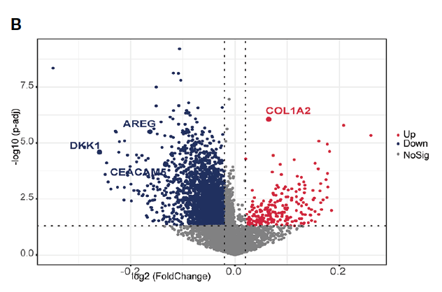

From https://www.frontiersin.org/articles/10.3389/fimmu.2022.1031184/full

FIGURE 5 Transcriptional and post-transcriptional characteristics related to WM_Score. (B) **The differences in the PDUI** of each gene between WM_Score_high and WM_Score_low groups.

## 0.3 应用场景 Application scenarios

TC3A (The Cancer 3′ UTR Atlas) 专门分析了TCGA 33种癌症类型的3′UTR长度，系统注释了可变多聚腺苷化位点APA (Alternative Polyadenylation, 可变多聚腺苷化)。

例文关注的是PAAD，可以套用于TCGA其他癌症类型。

使用火山图展示差异分析结果。也可以使用FigureYa其他作者绘制的更复杂的火山图：

- 一组：FigureYa59volcano ，FigureYa75baseVolcano
- 多组：FigureYa135multiVolcano

TC3A (The Cancer 3′ UTR Atlas) specifically analyzes the 3′UTR length of 33 cancer types in TCGA and systematically annotates alternative polyadenylation (APA) sites.

The example focuses on PAAD but can be adapted to other TCGA cancer types.

Use a volcano plot to display differential analysis results. Alternatively, more complex volcano plots created by other authors (e.g., FigureYa) can also be utilized.

- One group: FigureYa59volcano ，FigureYa75baseVolcano
- Multiple group: FigureYa135multiVolcano

## 0.4 环境设置 Environment Setup

```r
source("install_dependencies.R")
```

```
## Starting R package installation...
## ===========================================
##
## Installing TCGAbiolinks dependencies...
## Package already installed: AnnotationDbi
## Package already installed: httr2
## Package already installed: BiocFileCache
## Package already installed: curl
## Package already installed: rvest
## Package already installed: httr
##
## Installing CRAN packages...
## Package already installed: ggplot2
## Package already installed: ggrepel
## Package already installed: openxlsx
##
## Installing Bioconductor packages...
## Package already installed: TCGAbiolinks
## Package already installed: limma
##
## ===========================================
## Package installation completed!
## You can now run your R scripts in this directory.
```

```r
library(limma) # 线性模型拟合 Linear model fitting
library(ggplot2) # 绘图 Plotting
library(ggrepel) # 标签标注 Labeling
library(TCGAbiolinks) # TCGA数据下载 TCGA data download

# 显示英文报错信息
# Show English error messages
Sys.setenv(LANGUAGE = "en")

# 禁止chr转成factor
# Prevent character-to-factor conversion
options(stringsAsFactors = FALSE)
```

## 0.5 输入文件 Input Files

TCGA_PAAD_Combined_PDUIs.txt，从synapse网站中下载的TC3A_PDUI（Percentage of Distal polyA site Usage Index）的计算结果。下载地址：https://www.synapse.org/Synapse:syn24982198/files/（科学上网后注册下载），里面有TCGA其他癌症的PDUI数据，根据自己的研究兴趣灵活运用。

TCGA_PAAD.clin.txt，样本分组信息group。原文未提供分型信息，使用xenahttps://xenabrowser.net/datapages/下载的样本信息（TCGA Pancreatic Cancer (PAAD) (17 datasets) —— phenotype —— Phenotypes (n=196) TCGA Hub），点击链接下载：https://tcga-xena-hub.s3.us-east-1.amazonaws.com/download/TCGA.PAAD.sampleMap%2FPAAD_clinicalMatrix

TCGA_PAAD_Combined_PDUIs.txt, the calculation result of TC3A_PDUI (Percentage of Distal polyA site Usage Index) downloaded from the synapse website. Download url: https://doi.org/10.7303/syn24982198, there is a TCGA PDUI data of other cancers, according to their own research interests flexible use.

TCGA_PAAD.clin.txt, sample grouping information group. The original text does not provide typing information. The sample information downloaded using xena Download the https://tcga-xena-hub.s3.us-east-1.amazonaws.com/download/TCGA.PAAD.sampleMap%2FPAAD_clinicalMatrix

```r
# 读取PDUI信息和样本信息
# Reading PDUI data and sample info
PDUI <- read.table("TCGA_PAAD_Combined_PDUIs.txt", header = T)
rownames(PDUI) <- PDUI$event_id

# 移除前三列非数值列
# Remove first 3 non-numeric columns
PDUI <- PDUI[, -c(1:3)]

# 标准化样本ID
# Standardize sample IDs
colnames(PDUI) <- substr(colnames(PDUI), 1, 15)

group <- read.table("TCGA_PAAD.clin.txt", sep = "\t", header = T, row.names = 1)
rownames(group) <- gsub("-", "\\.", rownames(group))

samples <- intersect(rownames(group), colnames(PDUI))
PDUI <- PDUI[, samples]; group <- group[samples, ]

# 创建分组因子
# Create grouping factor
group <- setNames(object = ifelse(test = group$vital_status == "LIVING",
                                  yes = "LIVING", no = "DEAD"),
                  nm = samples)

# 设定测试组和对照组
# Set up the test group and the control group
group <- factor(group, levels = c("LIVING", "DEAD"))
```

## 0.6 进行差异分析 Differential Analysis

```r
# 创建设计矩阵
# Create design matrix
design <- model.matrix(~0 + factor(group))
colnames(design) = levels(factor(group))
rownames(design) = names(group)

# 设置对比组
# Set contrast (Test vs Control)
contrast.matrix <- makeContrasts(paste0(unique(group),collapse = "-"),
                                 levels = design)

# 线性模型拟合
# Linear model fitting
fit <- lmFit(PDUI[, names(group)], design)
fit2 <- contrasts.fit(fit, contrast.matrix)
fit2 <- eBayes(fit2) # Empirical Bayes Statistics for Differential Expression

# 获取差异分析结果
# Get differential analysis results
DEGs = topTable(fit2, coef=1, n=Inf)

# 添加基因注释
# Add gene annotations
DEGs$RefSeq <- gsub("(.+)\\|(.+)\\|(.+)\\|(.+)", "\\1", rownames(DEGs))
DEGs$SYMBOL <- gsub("(.+)\\|(.+)\\|(.+)\\|(.+)", "\\2", rownames(DEGs))
DEGs$CHR <- gsub("(.+)\\|(.+)\\|(.+)\\|(.+)", "\\3", rownames(DEGs))

# 保存结果
# Save results
openxlsx::write.xlsx(DEGs, "output_DEGs.xlsx")
```

## 0.7 开始画图 Start drawing the graph

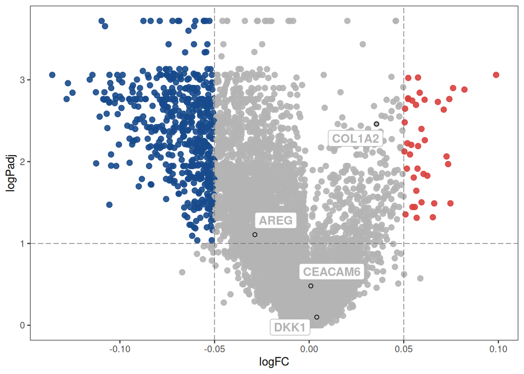

```r
# 准备绘图数据
# Prepare plotting data
plot.data <- DEGs
plot.data$logPadj <- -log(plot.data$adj.P.Val)

# 设置要标记的基因
# Genes to label
plotgene <- c("DKK1", "COL1A2", "AREG", "CEACAM6")
plot.data$label[plot.data$SYMBOL %in% plotgene] <- plot.data$SYMBOL[plot.data$SYMBOL %in% plotgene]

# 设置颜色分组
# Color grouping
plot.data$status <- "NoSig"
plot.data$status[plot.data$logFC < (-0.05) & plot.data$logPadj > 1] <- "Down"
plot.data$status[plot.data$logFC > 0.05 & plot.data$logPadj > 1] <- "Up"
plot.data$status <- factor(plot.data$status, levels = c("Up", "Down", "NoSig"))
plot.data$size <- abs(plot.data$logFC * plot.data$logPadj)

palette_volcano <- c(
  "Up" = "#D93F3C",
  "Down" = "#184A8C",
  "NoSig" = "#B3B3B3"
)

# 绘制火山图
# Draw volcano plot
ggplot(data = plot.data, aes(x = logFC, y = logPadj, color = status)) +
  geom_point(alpha = 0.9, size = 2.2) +
  scale_color_manual(values = palette_volcano, drop = FALSE) +
  scale_size_continuous(range=c(1, 8)) +
  geom_label_repel(
    data = subset(plot.data, !is.na(label)),
    aes(label = label, color = status),
    box.padding = unit(0.35, "lines"),
    point.padding = unit(0.3, "lines"),
    size = 4,
    fontface = "bold"
  )+
  geom_vline(xintercept = c(-0.05, 0.05), color="grey40", linetype="longdash", lwd = 0.25) +
  geom_hline(yintercept = 1, color="grey40", linetype="longdash", lwd = 0.25) +
  theme_bw() +
  theme(panel.grid=element_blank(), plot.title = element_text(hjust = 0.5), legend.position = "none") +
  geom_point(data = subset(plot.data, !is.na(label)),  alpha = 1, shape = 1,
             stroke = 0.5,
             color = "black")
```

```r
# 保存图片
# Save plot
ggsave("volcano.pdf", width = 6, height = 4)
```